# Fawn Nutrition Experiments

# Summary of the Data

White tail deer fawns of both sexes were collected in 1994 and were subjected to a feed regimen of one of three possible treatments 1) High-High (high protein feed throughout), 2) Low-Low (low protein feed throughout) or 3) Low-High (low protein feed in phase 1 followed by a high protein feed in phase 2). The ultimate goal was to determine if white tail deer exhibit compensatory growth. If so, we would expect to see that fawns subjected to a low protein diet in phase 1 followed by a high protein diet in phase 2, were able to catch up to their high-high treatment counterparts. There were mortalities observed throughout the study and across all treatment groups.

# Data Visualization

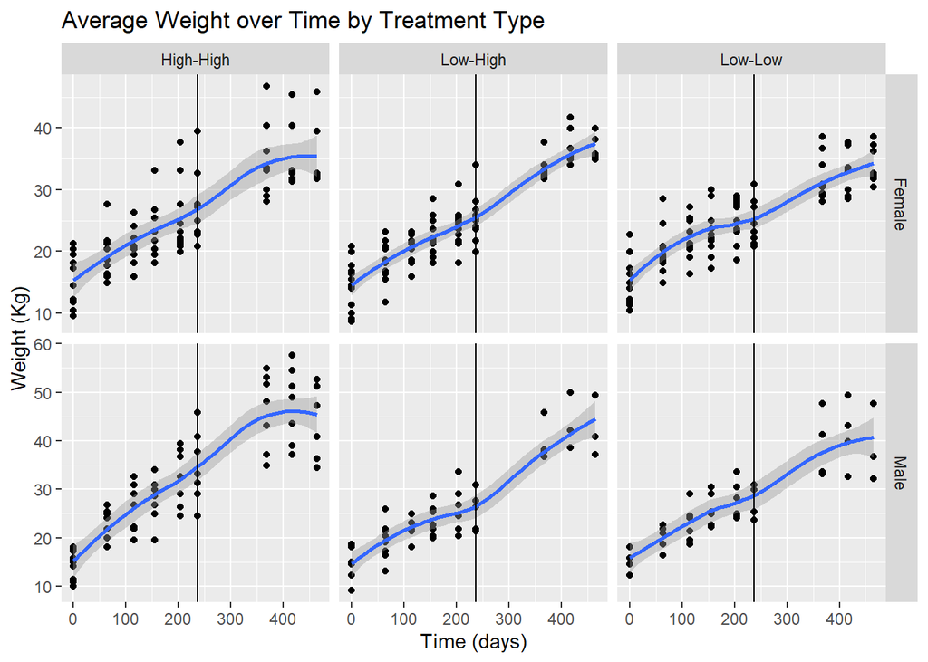

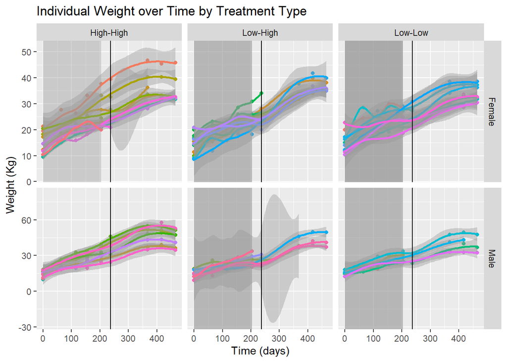

# Question 1: Were there weight differences among the treatment groups at the end of the study?

## Hypothesis 1: Deer body size (weight) is driven to cummulative nutrition.

### Prediction 1: The high-high group > low-high group > low-low group

## Hypothesis 2: Deer body size (weight) exhibit compensatory growth.

### Prediction 2: The high-high and low-high groups are similar but > low-low group

## Hypothesis 3: Deer body size (weight) is driven by nutirtional quality early in childhood and is not recoverable (permanently stunted).

### Prediction 3: The high-high group > both low-high and low-low groups which are similar to each other

## Hypothesis 4: Deer body size (weight) is not driven by nutritional quality.

### Prediction 4: There are no differences in body weights among the treatment groups.

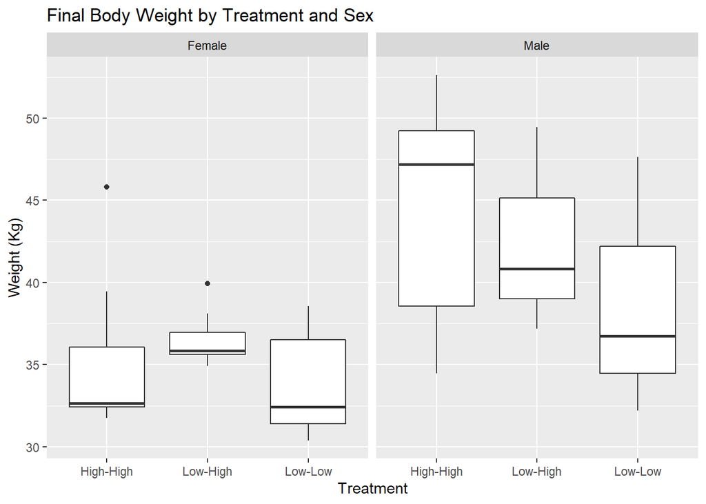

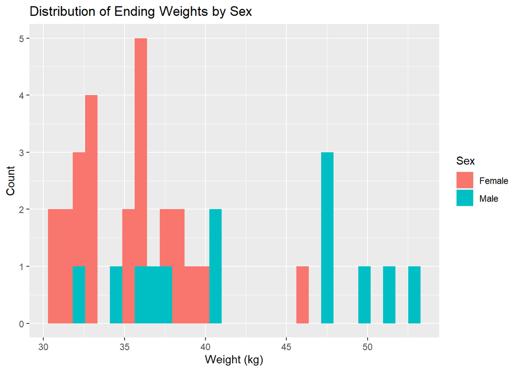

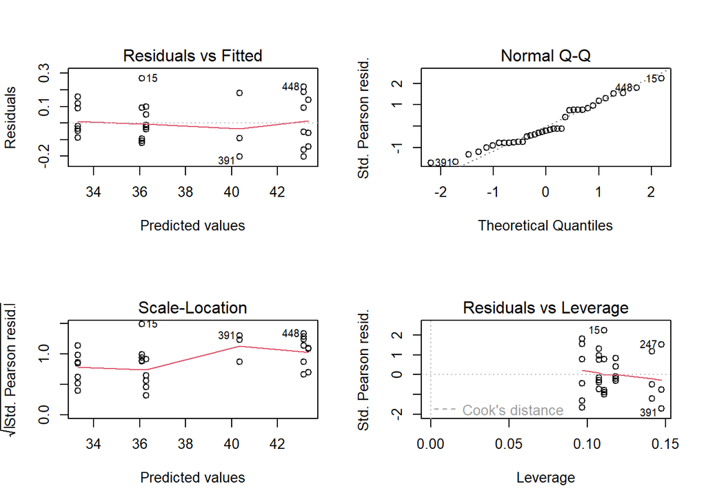

```
##
## Call:
## glm(formula = WEIGHT_KG ~ Sex + Treatment, family = Gamma(link = "identity"),
##     data = end_wts)
##
## Deviance Residuals:
##      Min        1Q    Median        3Q       Max
## -0.21756  -0.09537  -0.02519   0.09058   0.24849
##
## Coefficients:
##                   Estimate Std. Error t value Pr(>|t|)
## (Intercept)        36.0883     1.5377  23.469  < 2e-16 ***
## SexMale             7.0658     1.8293   3.863 0.000535 ***
## TreatmentLow-High   0.1989     2.0694   0.096 0.924030
## TreatmentLow-Low   -2.7922     1.9380  -1.441 0.159671
## ---
## Signif. codes:  0 '***' 0.001 '**' 0.01 '*' 0.05 '.' 0.1 ' ' 1
##
## (Dispersion parameter for Gamma family taken to be 0.01641995)
##
##     Null deviance: 0.85692  on 34  degrees of freedom
## Residual deviance: 0.50109  on 31  degrees of freedom
## AIC: 214.37
##
## Number of Fisher Scoring iterations: 5
```

```
## [1] 0.418214
```

There is not any evidence that female deer body weights are driven by nutrition. While the mean body weights for males appear to support prediction 1, there is too much variation within treatment groups to conclude that there is a relationship between body weight and treatment group for males (trend/means consistent with expectation, not significant/precise).

# Question 2: Did treatment groups experience different amounts of mortality?

## Hypothesis 1: Deer fawn mortality is related to nutritional quality (treatment).

### Prediction 1: The low-low group > low-high group > high-high group (more restricted individuals more likely to die).

### Prediction 2: The low-low group = low-high group > high-high group (individuals restricted earlier in life suffer higher rates of mortality)

### Prediction 3: The low-low group > low-high group = high-high group (individuals restricted later in life suffer higher rates of mortality).

### Prediction 4: Either low-low group = low-high group = high-high group or another arrangement (mortality not driven by nutritional content)

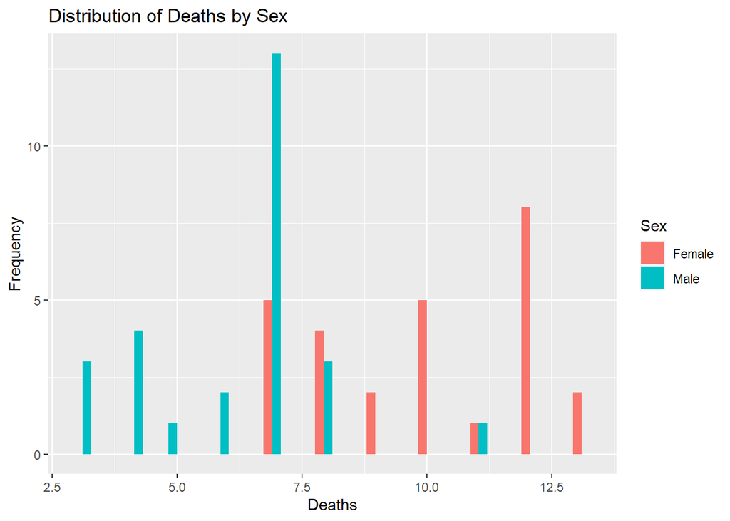

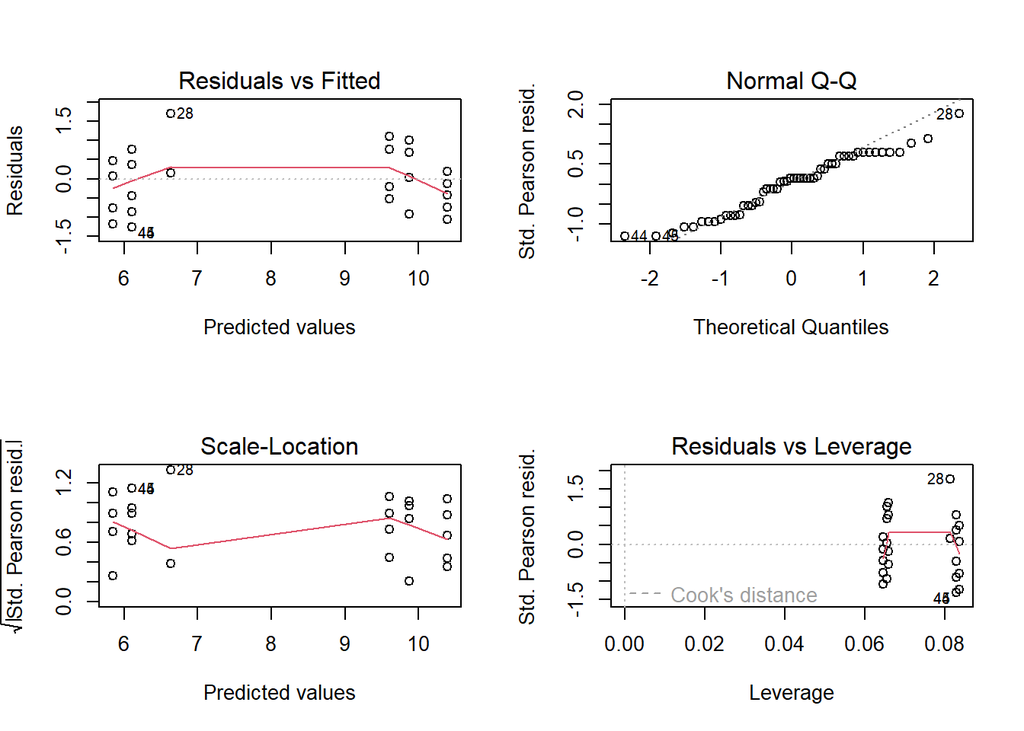

```
##              GVIF Df GVIF^(1/(2*Df))
## Sex       1.00009  1        1.000045
## Treatment 1.00009  2        1.000022
```

```
##
## Call:
## glm(formula = Count ~ Sex + Treatment, family = poisson(link = "identity"),
##     data = deaths)
##
## Deviance Residuals:
##     Min       1Q   Median       3Q      Max
## -1.3962  -0.5336   0.1430   0.6078   1.5493
##
## Coefficients:
##                   Estimate Std. Error z value Pr(>|z|)
## (Intercept)        10.3903     0.8199  12.673  < 2e-16 ***
## SexMale            -3.7618     0.7727  -4.868 1.13e-06 ***
## TreatmentLow-High  -0.5211     0.9321  -0.559    0.576
## TreatmentLow-Low   -0.7847     0.9238  -0.849    0.396
## ---
## Signif. codes:  0 '***' 0.001 '**' 0.01 '*' 0.05 '.' 0.1 ' ' 1
##
## (Dispersion parameter for poisson family taken to be 1)
##
##     Null deviance: 50.535  on 53  degrees of freedom
## Residual deviance: 26.646  on 50  degrees of freedom
## AIC: 244.5
##
## Number of Fisher Scoring iterations: 5
```

```
## [1] 0.5882493
```

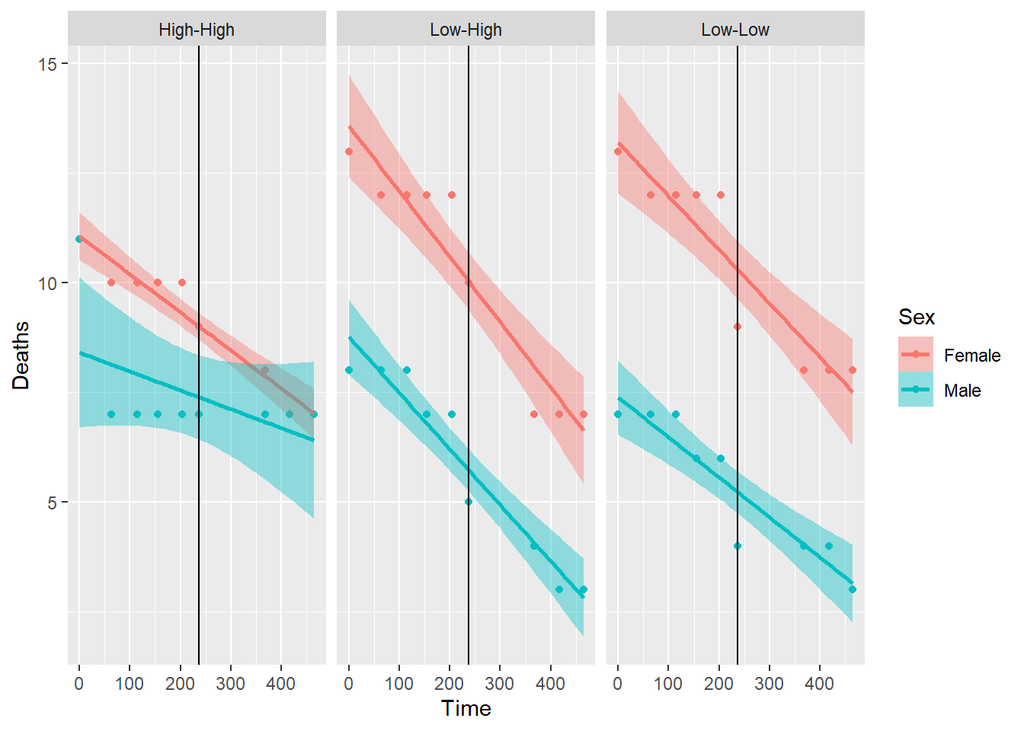

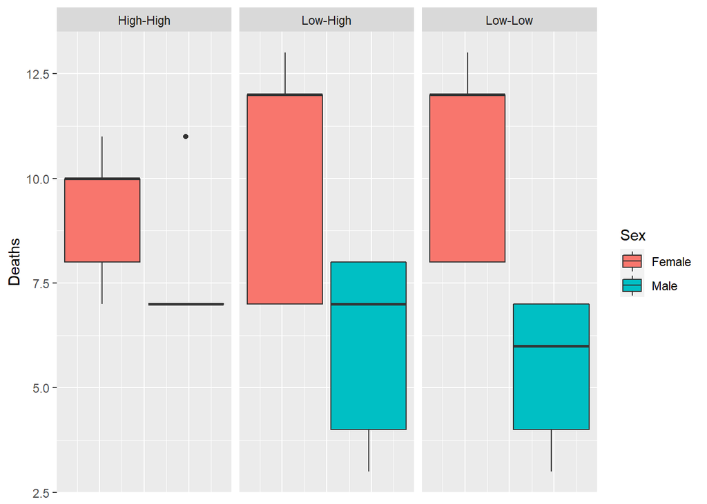

There does not appear to be any difference in deaths among the treatment groups.

# Question 3: Are there changes in growth rates between the treatment groups over time?

## Hypothesis 1: Treatment affects the starting rate of growth.

### Prediction 1: Intercepts: High-High > Low-High > Low-Low. With higher nutrition, higher intial rates of growth.

# Hypothesis 2: Treatment affects the trend of growth rate over time (decceleration).

## Prediction 2: Slopes: Low-Low > Low-High > High-High. With higher nutrition, higher decceleration (reach maximum body weight faster).

## Hypothesis 3: Treatment affects both the starting rate of growth and the rate of growth decceleration.

### Prediction 3: Intercepts: High-High > Low-High > Low-Low and Slopes: Low-Low > Low-High > High-High. With higher nutrition, higher inital rates of growth and greater decceleration (reaches maximum body rate faster).

## Hypothesis 4: Treatment does not appear to affect either intial growth rate or the rate of growth decceleration.

### Prediction 4: Intercepts and Slopes: High-High = Low-High = Low-Low

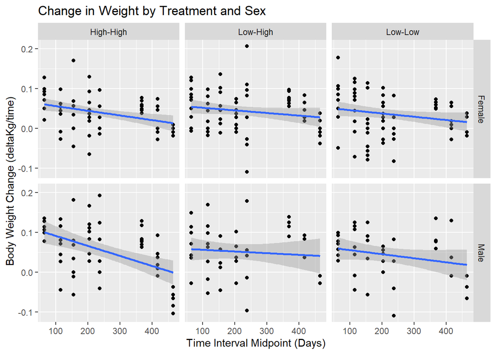

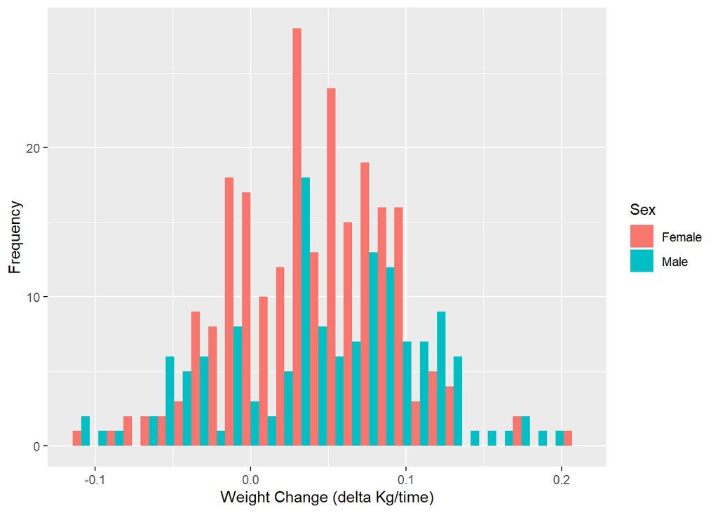

```
##
## Call:
## lm(formula = Wt_kg_rate ~ end_day + Treatment + end_day:Treatment,
##     data = males)
##
## Residuals:
##       Min        1Q    Median        3Q       Max
## -0.151460 -0.035848  0.002451  0.041344  0.135816
##
## Coefficients:
##                              Estimate Std. Error t value Pr(>|t|)
## (Intercept)                 6.568e-02  1.833e-02   3.583 0.000471 ***
## end_day                    -1.020e-04  7.242e-05  -1.409 0.161242
## TreatmentHigh-High          5.062e-02  2.493e-02   2.030 0.044272 *
## TreatmentLow-High          -5.216e-03  2.532e-02  -0.206 0.837129
## end_day:TreatmentHigh-High -1.498e-04  9.319e-05  -1.608 0.110246
## end_day:TreatmentLow-High   5.974e-05  1.027e-04   0.582 0.561771
## ---
## Signif. codes:  0 '***' 0.001 '**' 0.01 '*' 0.05 '.' 0.1 ' ' 1
##
## Residual standard error: 0.06051 on 136 degrees of freedom
##   (34 observations deleted due to missingness)
## Multiple R-squared:  0.1357, Adjusted R-squared:  0.104
## F-statistic: 4.272 on 5 and 136 DF,  p-value: 0.00122
```

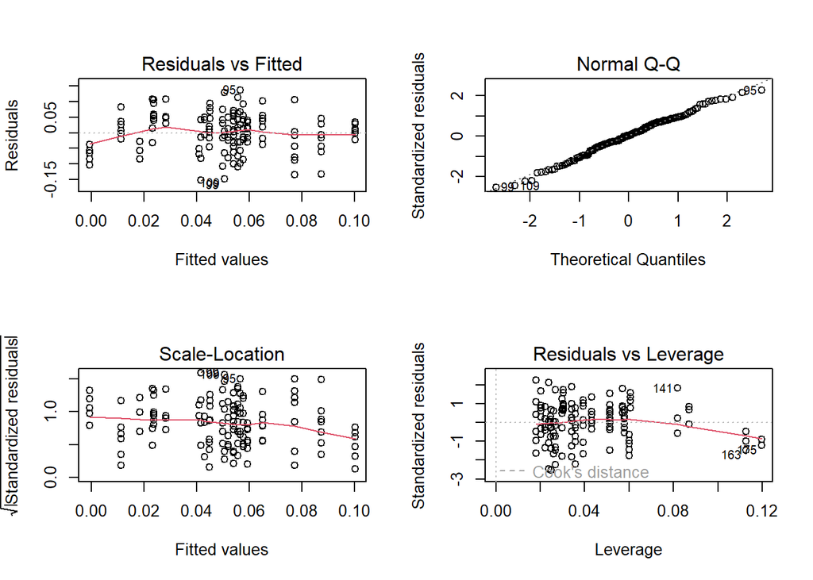

```
##
## Call:
## lm(formula = Wt_kg_rate ~ end_day + Treatment + end_day:Treatment,
##     data = females)
##
## Residuals:
##       Min        1Q    Median        3Q       Max
## -0.152754 -0.033759  0.000835  0.034711  0.163385
##
## Coefficients:
##                              Estimate Std. Error t value Pr(>|t|)
## (Intercept)                 5.405e-02  1.068e-02   5.061 8.65e-07 ***
## end_day                    -8.245e-05  4.024e-05  -2.049   0.0416 *
## TreatmentHigh-High          1.356e-02  1.578e-02   0.860   0.3908
## TreatmentLow-High           4.281e-03  1.518e-02   0.282   0.7783
## end_day:TreatmentHigh-High -3.473e-05  5.898e-05  -0.589   0.5566
## end_day:TreatmentLow-High   1.688e-05  5.811e-05   0.291   0.7717
## ---
## Signif. codes:  0 '***' 0.001 '**' 0.01 '*' 0.05 '.' 0.1 ' ' 1
##
## Residual standard error: 0.04828 on 225 degrees of freedom
##   (41 observations deleted due to missingness)
## Multiple R-squared:  0.06373,    Adjusted R-squared:  0.04293
## F-statistic: 3.063 on 5 and 225 DF,  p-value: 0.01073
```

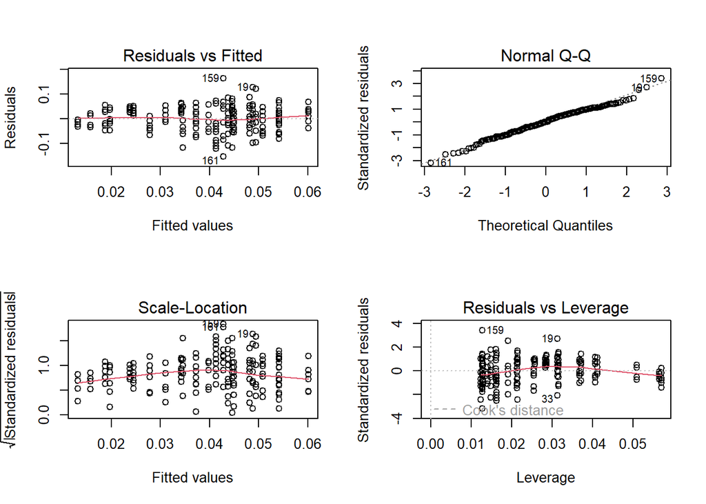

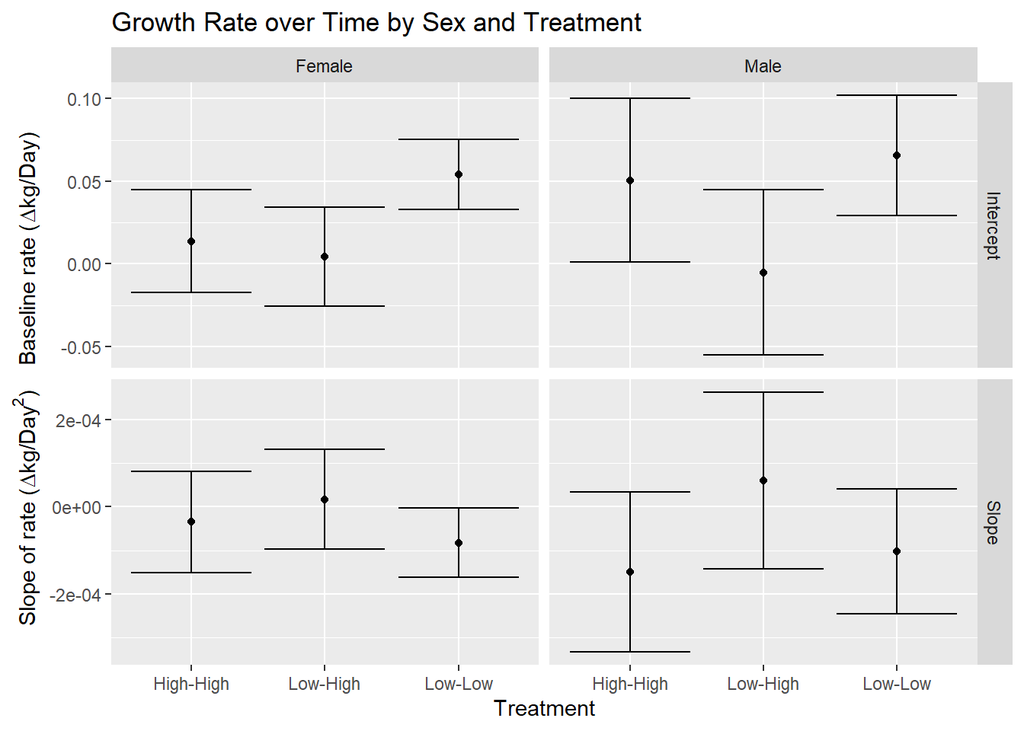